# Budapest Property Market: Tools for Predictive Modelling

Benoît Guillaud

21 June 2017

# Abstract

This is the second in a serie of three papers to illustrate the use of simple R tools for the analysis of a city’s Real Property market. We focus here the use of machine learning algorithms to predict the rental value and the selling price of a property, based on a set of predictors.

Note that the paper focuses on the method rather than the actual prediction performance. Indeed, the intention is to show how to build simple models that can be used as surrogates in an optimizazion routine. The optimization itself is the subject of the third and last paper.

Along the way, we will learn how to:

- Prepare a dataset for analysis - Select the variables with `dplyr::select()`
- Create training and testing sets - Randomly split the data with `caret::createDataPartition()`
- Build and evalate predictive models - Train model with multiple algorithms with `caret::train()`

# Load and prepare the datasets

Only basic information about the properties are used make predictions:

| Feature | Description | Type |
| --- | --- | --- |
| ppsm | Price per square meter in kFt/m2 | Float |
| rpsm | Rent per square meter in kFt/m2/year | Float |
| area | Flat floor area (mezzanine NOT included) | Integer |
| district | District wehre the property is located | String |
| varos | Administrative division inside the district | String |
| lift | Presence of an elevator | Boolean |

Additionally, the price and the annual rent of a flat is always given in mFt.

### Load the data

```r
# Load the data
elado <- read.csv("./data/extraction_elado_2017_03_16.txt",
                  fileEncoding="UTF-8-BOM", header=TRUE, sep=";")
kiado <- read.csv("./data/extraction_kiado_2017_03_16.txt",
                  fileEncoding="UTF-8-BOM", header=TRUE, sep=";")

# Clean and recode the variables
elado <- PrepareData(elado)
kiado <- PrepareData(kiado)

# Create new variable ppsm and rpsm from "price"
elado <- dplyr::mutate(elado, ppsm = price*1000/area)    # kFt/m2
kiado <- dplyr::mutate(kiado,
                       rent = price*12/1000,             # mFt/year
                       rpsm = price*12/area)             # kFt/m2/year


# select the features of interest
elado <- dplyr::select(elado, price, ppsm, area, varos, district,
                       lift, floor, balcony, view, condition, heating, aircon, orient)
kiado <- dplyr::select(kiado, rent, rpsm, area, varos, district,
                       lift, floor, balcony, view, condition, heating, aircon, orient)
```

### Further prepare dataset

It’s also good practice to identify class imbalances and remove the categories that are not represented:

```r
nonWantedLevels<-c(4, 11)
elado <- elado %>%
  dplyr::filter(!as.integer(varos) %in% nonWantedLevels) %>%
  droplevels()
```

We also impute missing values to increase the number of training examples available for training and testing our model:

```r
elado$balcony <- ifelse(is.na(elado$balcony), 0, elado$balcony)
kiado$balcony <- ifelse(is.na(kiado$balcony), 0, kiado$balcony)

elado$aircon <- ifelse(is.na(elado$aircon), 0, elado$aircon)
kiado$aircon <- ifelse(is.na(kiado$aircon), 0, kiado$aircon)
```

The previous paper indicated that the set has no near-zero-value variables. Any feature engineering could also be performed as part of this step.

### Build training and testing sets

There are (at least) 2 was to randomly split the dataset into a training and testing sets. We choose here to split according to outcome, in order to have balanced dataset according to variables price and rent.

```r
# elado
set.seed(2)
  ## based on outcome
  inTrain <- caret::createDataPartition(elado$price, p=0.75,list = FALSE)
  ## based on predictors
  # index <- maxDissim()
elado.train <- elado[inTrain,]
elado.test <-  elado[-inTrain,]

# kiado
set.seed(2)
  ## based on outcome
  inTrain <- caret::createDataPartition(kiado$rent, p=0.75,list = FALSE)
  ## based on predictors
  # index <- maxDissim()
kiado.train <- kiado[inTrain,]
kiado.test <-  kiado[-inTrain,]
```

# Build predictive models

In this section, we build several predictive models to see which one best fits the data. The models are trained on the training set and evaluated on the testing set. Their parameters are optimized through cross-validation (on the training set).

The evaluation is done through visualization and quantitative performance measures:

- Plot of residuals vs. observed values
- Plot of predicted values vs. observed values
- Sum of squared root errors

### Baseline model

The baseline model consists of predicting the selling price of a property as the median value in that varos. The baseline is a simple measure used as benchmark for more sophisticated models.

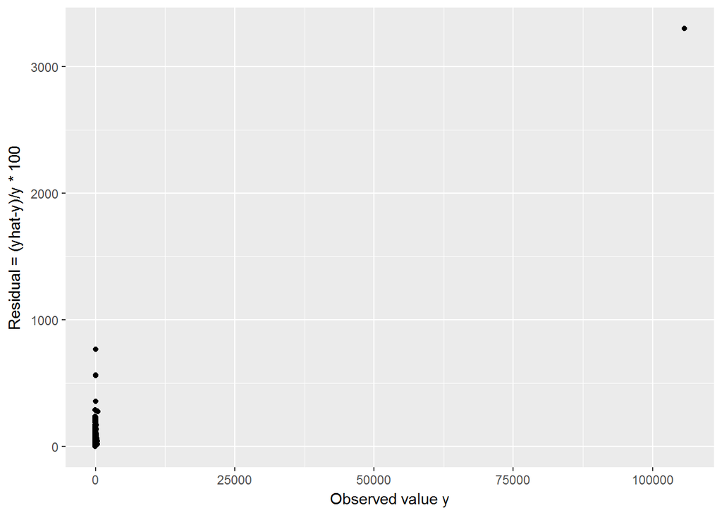

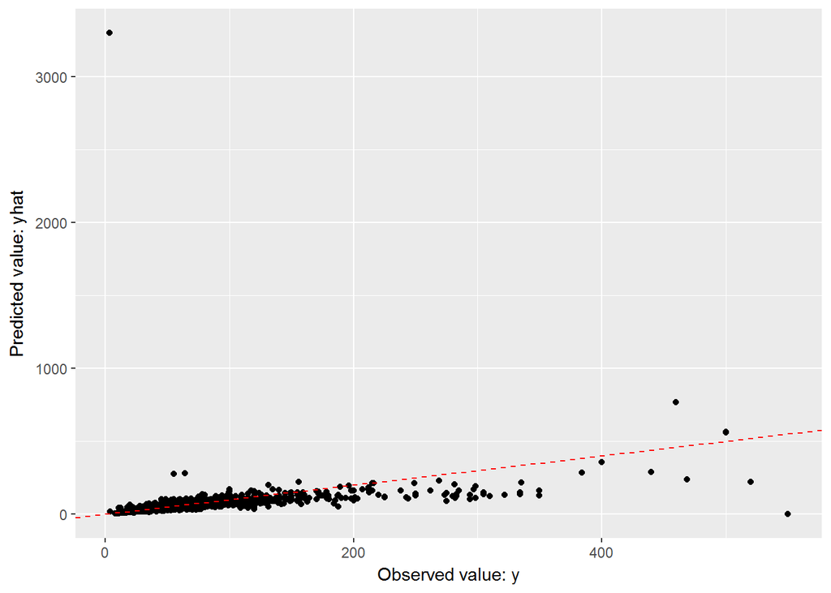

```
##       RMSE   Rsquared
## 67.1776718  0.1835422
```

```r
# find the median PPSM in each varos (training set)
elado.train.by_varos <- elado.train %>%
  dplyr::group_by(varos) %>%
  dplyr::summarise(n = n(),
                   avg.ppsm = mean(ppsm),
                   med.ppsm = median(ppsm)) %>%
  dplyr::ungroup()

# join to mimic VLOOKUP, then make predictions (testing set)
elado.test <- dplyr::inner_join(elado.test, elado.train.by_varos, by=c("varos"))
elado.test <- dplyr::mutate(elado.test, price.pred = med.ppsm * area / 1000)

# model evaluation
with(elado.test,
     EvaluateModel(price, price.pred))
```

The baseline model predics the property selling price with a high RMSE and R2=0.18, probably driven by a few outliers.

### Linear regression

Use `caret::` to build a simple regression linear model with 3 predictors: area, varos and whether there is a lift or not.

```r
# Set the resampling method and options
ctrl <- caret::trainControl(## n-fold CV
                            method = "repeatedcv",
                            number = 10,
                            ## repeated k times
                            repeats = 3)

price_mod_lm.A <- caret::train(price ~ area + varos + lift,
                               data = elado.train,
                               na.action = na.omit,
                               method = "lm",
                               tuneLength = 15,
                               trControl = ctrl)
                               #preProc = c("BoxCox", "center", "scale"))

# model summary
summary(price_mod_lm.A)
```

```
##
## Call:
## lm(formula = .outcome ~ ., data = dat)
##
## Residuals:
##      Min       1Q   Median       3Q      Max
## -1174.89   -13.05    -3.27     6.08   415.38
##
## Coefficients:
##                                            Estimate Std. Error t value Pr(>|t|)
## (Intercept)                               -0.532681   1.279134  -0.416 0.677101
## area                                       0.526078   0.007035  74.777  < 2e-16 ***
## `varosBelso-Terézváros`                   16.040928   1.385085  11.581  < 2e-16 ***
## varosBelváros                             28.130924   1.415031  19.880  < 2e-16 ***
## `varosKözépso-Erzsébetváros`              -6.034838   1.650624  -3.656 0.000258 ***
## `varosKülso-Erzsébetváros`                -8.986534   1.702840  -5.277 1.35e-07 ***
## `varosKülso-Erzsébetváros  Ligetváros`   -7.794887   1.918999  -4.062 4.92e-05 ***
## `varosKülso-Terézváros`                   -1.838415   1.350367  -1.361 0.173423
## `varosKülso-Terézváros  Diplomatanegyed`  2.705844   2.433678   1.112 0.266246
## varosLipótváros                           26.562275   1.474609  18.013  < 2e-16 ***
## liftvan                                   11.288796   0.878625  12.848  < 2e-16 ***
## ---
## Signif. codes:  0 '***' 0.001 '**' 0.01 '*' 0.05 '.' 0.1 ' ' 1
##
## Residual standard error: 32.38 on 7398 degrees of freedom
## Multiple R-squared:  0.5446, Adjusted R-squared:  0.544
## F-statistic: 884.7 on 10 and 7398 DF,  p-value: < 2.2e-16
```

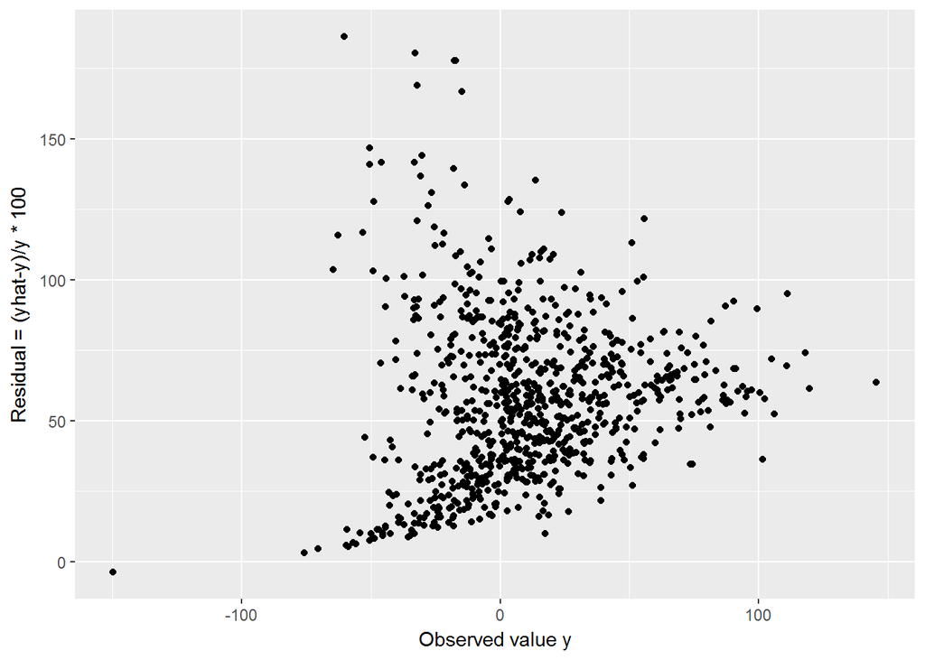

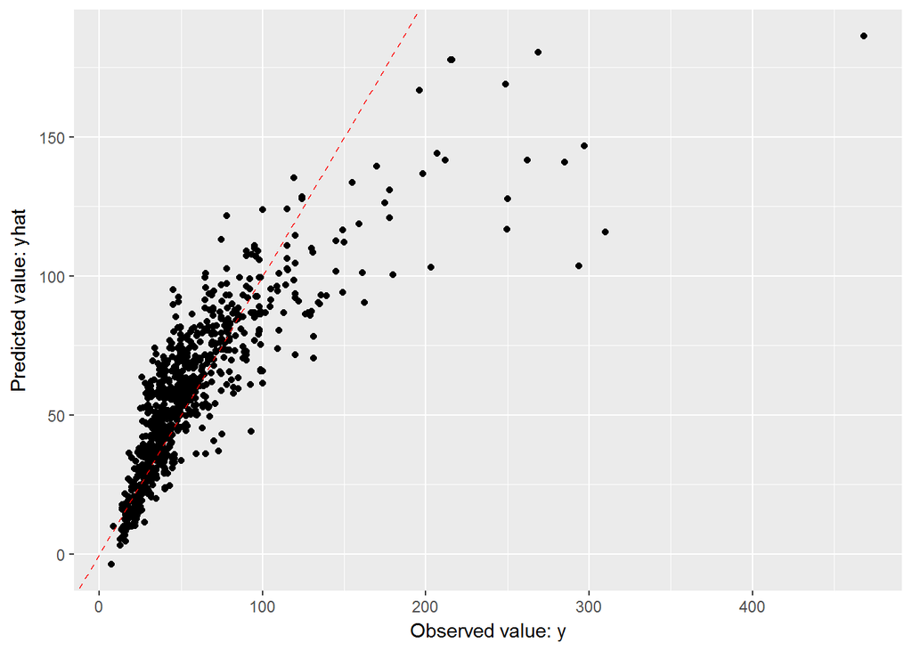

```
##       RMSE   Rsquared
## 24.6143590  0.6781092
```

```r
# Predictions on testing set
price_pred_lm.A <- predict(price_mod_lm.A, newdata=na.omit(elado.test))

# evaluate model on testing set
with(subset(na.omit(elado.test)),
     EvaluateModel(price, price_pred_lm.A))
```

Notes:

- R2 = 0.68 is already much better than the baseline
- The BoxCox transformation seems to degrade the result (R2=0.57)

### Regression tree (CART)

CART model with parameter optimisation through cross-validation using `caret::` package, using the same 3 features as for the linear regression model above (varos, area, lift) for comparison.

```r
# resampling method and cross-validation options
ctrl <- caret::trainControl(## n-fold CV
                            method = "cv",
                            number = 10,
                            ## repeated k times
                            repeats = 3)

cpGrid = expand.grid( .cp = c(1e-14, 1e-13, 1e-12, 1e-11, 1e-10, 1e-9, 1e-8, 1e-7, 1e-6, 1e-5, 1e-4, 1e-3, 1e-2))

# cross validation
price_cv_cart.A <- caret::train(price ~ area + varos + lift,
                               data = elado.train,
                               na.action = na.pass,
                               method = "rpart",
                               trControl = ctrl,
                               tuneGrid = cpGrid,
                               preProc = c("BoxCox", "center", "scale"))

# cross-validation results
print(price_cv_cart.A)
```

[output not shown]

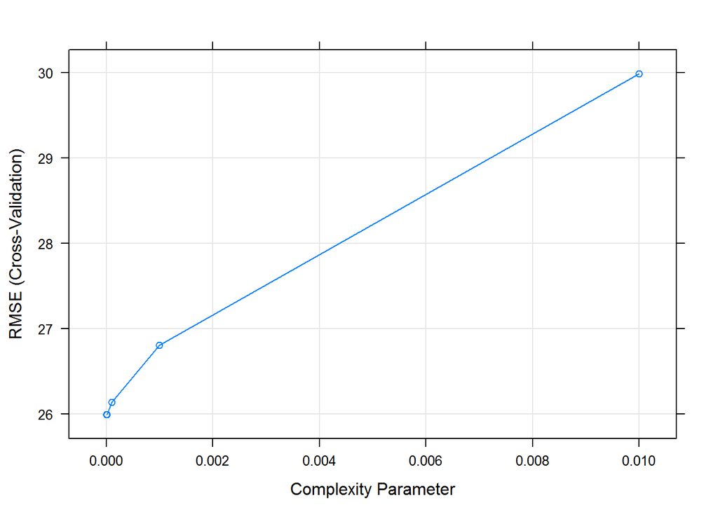

```r
plot(price_cv_cart.A)
```

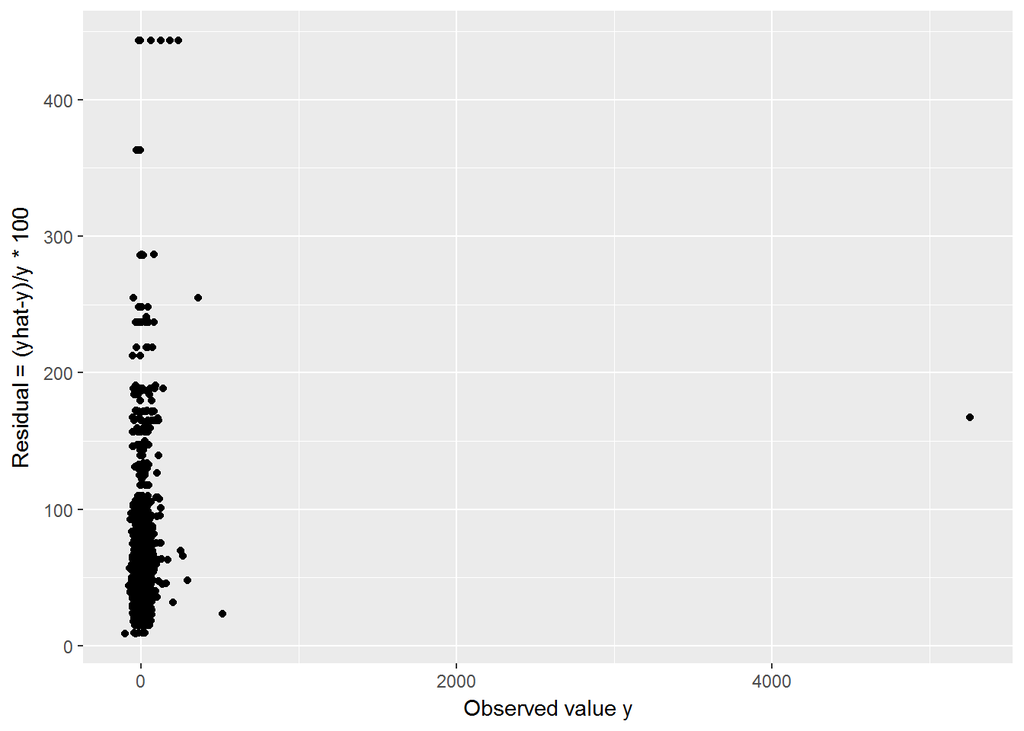

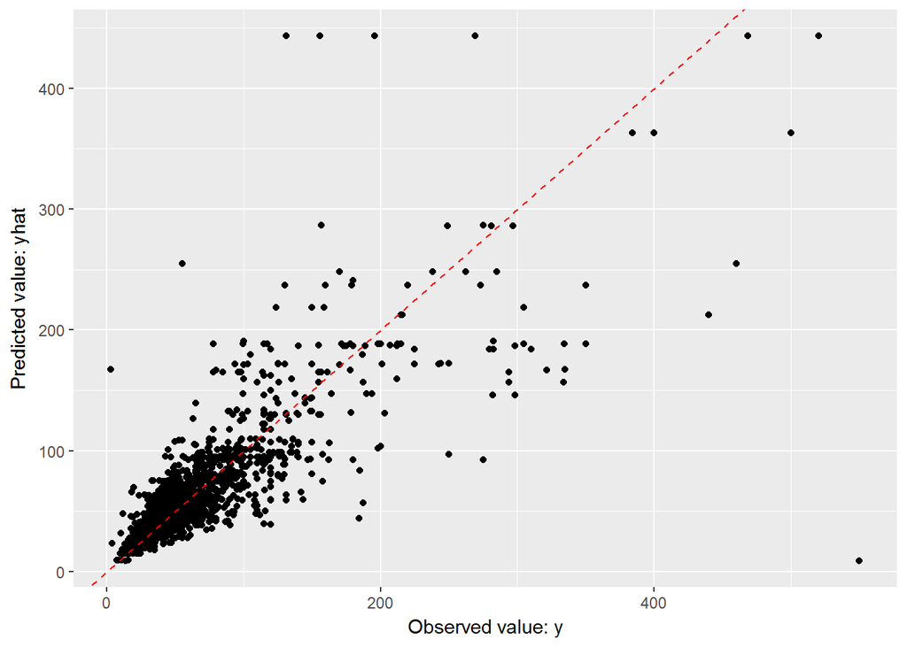

```
##       RMSE   Rsquared
## 26.3792230  0.7072092
```

```r
# CART model with optimized cp
price_mod_rpart.A <- rpart::rpart(price ~ area + varos + lift, data = elado.train, cp = 1e-5)

# predictions on testing set
price_pred_rpart.A = predict(price_mod_rpart.A, newdata = elado.test)


# evaluate model on testing set
with(elado.test,
     EvaluateModel(price, price_pred_rpart.A))
```

Notes:

- With R2=0.71, the CART algorithm offers further improvement compared to the equivalent linear regression.
- CART algorithm seems insensitive to pre-processing
- For CART, na.action = na.pass to retain as much data as possible
- Using all the variables in the dataset (not just 3) would improve the predictive performance. The observed RMSE is then R2=0.75

## Other models

The `caret::` package makes it easy to try many other algorithms, such as random forests or support vector machine. With no a priori knowledge of the problem, it is highly recommended to try many different algorithms to find out which one(s) perform well for the problem at hand.